# Reverse Proxy Guide

In addition to being a "basic" web server, and providing static and dynamic content to end-users, Apache httpd (as well as most other web servers) can also act as a reverse proxy server, also-known-as a "gateway" server.

In such scenarios, httpd itself does not generate or host the data, but rather the content is obtained by one or several backend servers, which normally have no direct connection to the external network. As httpd receives a request from a client, the request itself is *proxied* to one of these backend servers, which then handles the request, generates the content and then sends this content back to httpd, which then generates the actual HTTP response back to the client.

There are numerous reasons for such an implementation, but generally the typical rationales are due to security, high-availability, load-balancing and centralized authentication/authorization. It is critical in these implementations that the layout, design and architecture of the backend infrastructure (those servers which actually handle the requests) are insulated and protected from the outside; as far as the client is concerned, the reverse proxy server *is* the sole source of all content.

A typical implementation is below:

[figure not shown]

## Reverse Proxy

Related Modules

Related Directives

- `mod_proxy`
- `mod_proxy_balancer`
- `mod_proxy_hcheck`
- `ProxyPass`
- `BalancerMember`

## Simple reverse proxying

The `ProxyPass` directive specifies the mapping of incoming requests to the backend server (or a cluster of servers known as a `Balancer` group). The simplest example proxies all requests (`"/"`) to a single backend:

```
ProxyPass "/"  "http://www.example.com/"
```

To ensure that and `Location:` headers generated from the backend are modified to point to the reverse proxy, instead of back to itself, the `ProxyPassReverse` directive is most often required:

```
ProxyPass "/"  "http://www.example.com/"
ProxyPassReverse "/"  "http://www.example.com/"
```

Only specific URIs can be proxied, as shown in this example:

```
ProxyPass "/images"  "http://www.example.com/"
ProxyPassReverse "/images"  "http://www.example.com/"
```

In the above, any requests which start with the `/images` path with be proxied to the specified backend, otherwise it will be handled locally.

## Clusters and Balancers

As useful as the above is, it still has the deficiencies that should the (single) backend node go down, or become heavily loaded, that proxying those requests provides no real advantage. What is needed is the ability to define a set or group of backend servers which can handle such requests and for the reverse proxy to load balance and failover among them. This group is sometimes called a *cluster* but Apache httpd's term is a *balancer*. One defines a balancer by leveraging the `<Proxy>` and `BalancerMember` directives as shown:

```
<Proxy balancer://myset>
    BalancerMember http://www2.example.com:8080
    BalancerMember http://www3.example.com:8080
    ProxySet lbmethod=bytraffic
</Proxy>

ProxyPass "/images/"  "balancer://myset/"
ProxyPassReverse "/images/"  "balancer://myset/"
```

The `balancer://` scheme is what tells httpd that we are creating a balancer set, with the name *myset*. It includes 2 backend servers, which httpd calls *BalancerMembers*. In this case, any requests for `/images` will be proxied to *one* of the 2 backends. The `ProxySet` directive specifies that the *myset* Balancer use a load balancing algorithm that balances based on I/O bytes.

**Hint**

*BalancerMembers* are also sometimes referred to as *workers*.

## Balancer and BalancerMember configuration

You can adjust numerous configuration details of the *balancers* and the *workers* via the various parameters defined in `ProxyPass`. For example, assuming we would want `http://www3.example.com:8080` to handle 3x the traffic with a timeout of 1 second, we would adjust the configuration as follows:

```
<Proxy balancer://myset>
    BalancerMember http://www2.example.com:8080
    BalancerMember http://www3.example.com:8080 loadfactor=3 timeout=1
    ProxySet lbmethod=bytraffic
</Proxy>

ProxyPass "/images"  "balancer://myset/"
ProxyPassReverse "/images"  "balancer://myset/"
```

## Failover

You can also fine-tune various failover scenarios, detailing which workers and even which balancers should be accessed in such cases. For example, the below setup implements three failover cases:

1. `http://spare1.example.com:8080` and `http://spare2.example.com:8080` are only sent traffic if one or both of `http://www2.example.com:8080` or `http://www3.example.com:8080` is unavailable. (One spare will be used to replace one unusable member of the same balancer set.)
2. `http://hstandby.example.com:8080` is only sent traffic if all other workers in balancer set `0` are not available.
3. If all load balancer set `0` workers, spares, and the standby are unavailable, only then will the `http://bkup1.example.com:8080` and `http://bkup2.example.com:8080` workers from balancer set `1` be brought into rotation.

Thus, it is possible to have one or more hot spares and hot standbys for each load balancer set.

```
<Proxy balancer://myset>
    BalancerMember http://www2.example.com:8080
    BalancerMember http://www3.example.com:8080 loadfactor=3 timeout=1
    BalancerMember http://spare1.example.com:8080 status=+R
    BalancerMember http://spare2.example.com:8080 status=+R
    BalancerMember http://hstandby.example.com:8080 status=+H
    BalancerMember http://bkup1.example.com:8080 lbset=1
    BalancerMember http://bkup2.example.com:8080 lbset=1
    ProxySet lbmethod=byrequests
</Proxy>

ProxyPass "/images/"  "balancer://myset/"
ProxyPassReverse "/images/"  "balancer://myset/"
```

For failover, hot spares are used as replacements for unusable workers in the same load balancer set. A worker is considered unusable if it is draining, stopped, or otherwise in an error/failed state. Hot standbys are used if all workers and spares in the load balancer set are unavailable. Load balancer sets (with their respective hot spares and standbys) are always tried in order from lowest to highest.

## Balancer Manager

One of the most unique and useful features of Apache httpd's reverse proxy is the embedded *balancer-manager* application. Similar to `mod_status`, *balancer-manager* displays the current working configuration and status of the enabled balancers and workers currently in use. However, not only does it display these parameters, it also allows for dynamic, runtime, on-the-fly reconfiguration of almost all of them, including adding new *BalancerMembers* (workers) to an existing balancer. To enable these capability, the following needs to be added to your configuration:

```
<Location "/balancer-manager">
    SetHandler balancer-manager
    Require host localhost
</Location>
```

**Warning**

Do not enable the *balancer-manager* until you have secured your server. In particular, ensure that access to the URL is tightly restricted.

When the reverse proxy server is accessed at that url (eg: `http://rproxy.example.com/balancer-manager/`, you will see a page similar to the below:

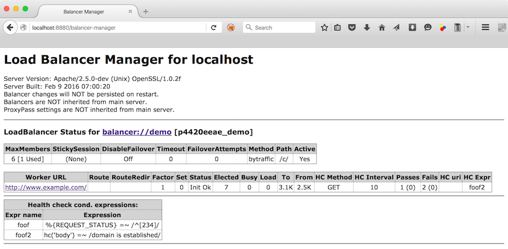

This form allows the devops admin to adjust various parameters, take workers offline, change load balancing methods and add new works. For example, clicking on the balancer itself, you will get the following page:

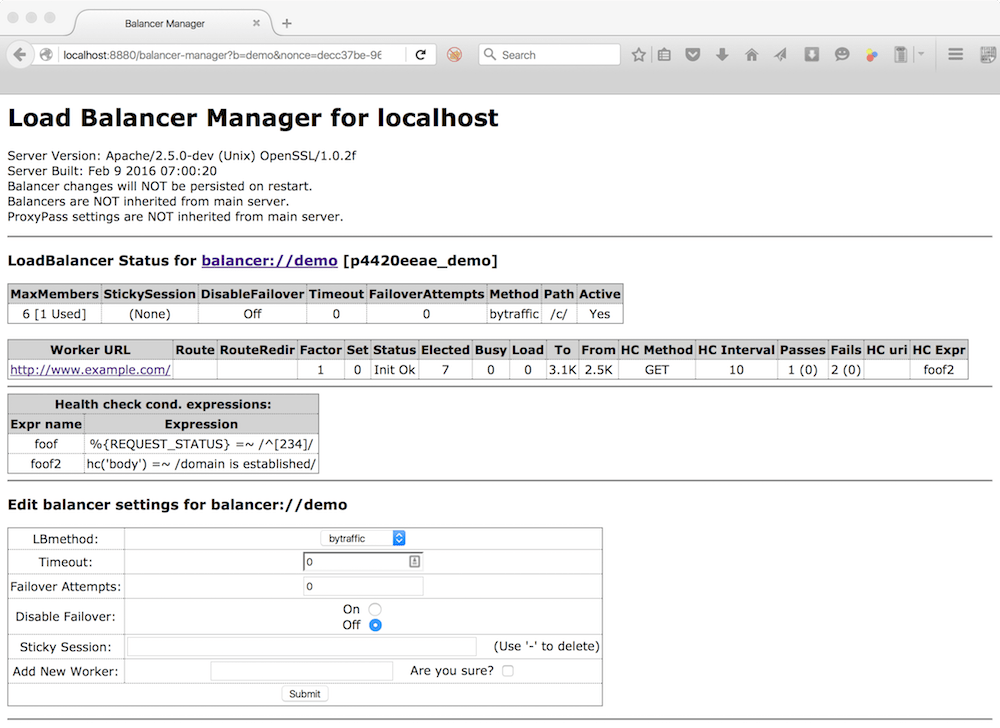

Whereas clicking on a worker, displays this page:

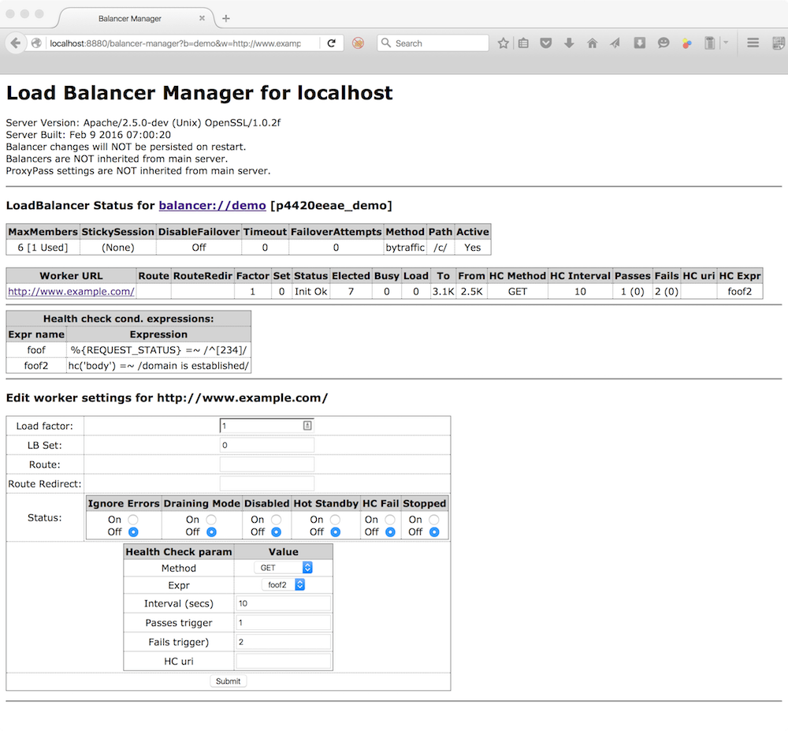

To have these changes persist restarts of the reverse proxy, ensure that `BalancerPersist` is enabled.

## Dynamic Health Checks

Before httpd proxies a request to a worker, it can *"test"* if that worker is available via setting the `ping` parameter for that worker using `ProxyPass`. Oftentimes it is more useful to check the health of the workers *out of band*, in a dynamic fashion. This is achieved in Apache httpd by the `mod_proxy_hcheck` module.

## BalancerMember status flags

In the *balancer-manager* the current state, or *status*, of a worker is displayed and can be set/reset. The meanings of these statuses are as follows:

[output not shown]

© 2018 The Apache Software Foundation  
Licensed under the Apache License, Version 2.0.  
https://httpd.apache.org/docs/2.4/en/howto/reverse_proxy.html